# Final Project

Ryan Kelly

2026-03-30

## Introduction

This project analyzes annual U.S. energy generation by source from **2014** to **2024** using data imported from the U.S. Energy Information Administration (EIA), specifically the “Net generation by energy source: Total (all sectors)” dataset. I cleaned the dataset in Excel to include six variables: Year, Coal, Natural Gas, Nuclear, Hydroelectric, and Solar.

The purpose of this analysis is to examine how major energy sources have changed over time, compare fossil fuel and renewable energy patterns, and evaluate whether there are clear linear trends in energy generation across the study timeline.

## Research Question

Are there statistically significant trends in U.S. energy generation over time, and is there evidence of a transition from fossil fuels to renewable energy sources?

## Methods

This analysis applies descriptive statistics, data visualization, and linear regression to analyze trends in U.S. energy generation over time. Descriptive statistics are used to summarize central tendency and variability across energy sources. Time series plots and comparative graphs are used to identify patterns, trends, and relationships between fossil fuels and renewable energy sources. Linear regression models are then applied to quantify the direction and strength of trends over time, allowing for a more formal evaluation of changes in energy generation across the dataset.

## Statistical Significance and Model Specification

All statistical tests used an α = 0.05 significance level. Linear regression models followed the general formula:

**Y = β0 + β1(Year) + ε**

Y represents annual energy generation (in million MWh), β0 is the intercept, β1 is the slope coefficient representing annual change, and ε is the error term. Model assumptions (linearity and normality of residual) were evaluated using diagnostic plots.

## Libraries

```r
library(readr)
library(dplyr)
library(tidyr)
library(ggplot2)
library(broom)
library(scales)
library(readxl)
library(knitr)
library(kableExtra)
library(knitr)
library(tibble)
library(forecast)
```

## Import Data

```r
data <- read_excel("epa_03_01_a_cleaned.xlsx")
```

## View Structure of the Data

```r
#data dimensions
data.frame(
  Metric = c("Rows", "Columns"),
  Value = c(nrow(data), ncol(data))
) %>%
kable(caption = "Dataset Dimensions") %>%
kable_styling(
  full_width = FALSE,
  bootstrap_options = c("striped", "hover", "condensed"),
  position = "center"
) %>%
  row_spec(0, bold = TRUE)
```

Dataset Dimensions

| Metric | Value |
| --- | --- |
| Rows | 11 |
| Columns | 6 |

## Column Names

```r
#column names
data.frame(
  Columns = colnames(data)) %>%
  kable(caption = "Column Names", align = "c") %>%
  kable_styling(
    full_width = FALSE,
    bootstrap_options = c("striped", "hover", "condensed"),
    position = "center"
) %>%
  row_spec(0, bold = TRUE)
```

Column Names

| Columns |
| --- |
| Year |
| Coal |
| Natural_Gas |
| Nuclear |
| Hydroelectric |
| Solar |

## Preview Data

```r
#preview data
data %>%
  head() %>%
  kable(caption = "Preview of Dataset (First 6 Rows)") %>%
  kable_styling(
    full_width = FALSE,
    bootstrap_options = c("striped", "hover", "condensed"),
  position = "center"
) %>%
  row_spec(0, bold = TRUE)
```

Preview of Dataset (First 6 Rows)

| Year | Coal | Natural_Gas | Nuclear | Hydroelectric | Solar |
| --- | --- | --- | --- | --- | --- |
| 2014 | 1581710 | 1126635 | 797166 | 259367 | 17691 |
| 2015 | 1352398 | 1334668 | 797178 | 249080 | 24893 |
| 2016 | 1239149 | 1379271 | 805694 | 267812 | 36054 |
| 2017 | 1205835 | 1297703 | 804950 | 300333 | 53287 |
| 2018 | 1149487 | 1471843 | 807084 | 292524 | 63825 |
| 2019 | 964957 | 1588533 | 809409 | 287874 | 71937 |

**Observation**

The preview of the dataset shows consistent patterns across the variables (coal decreases over time, natural gas increases, solar displays growth, nuclear and hydroelectric values remain stable). Based on this preview, the dataset appears clean and properly formatted, indicating it is ready for analysis.

## Data Quality Check - Missing Values

```r
missing_values <- data.frame(
  Variable = colnames(data),
  Missing_Count = colSums(is.na(data)),
  Missing_Percent = round(colMeans(is.na(data)) * 100, 2)
)

missing_values %>%
  kable(caption = "Missing Values Analysis") %>%
  kable_styling(
    full_width = FALSE,
    bootstrap_options = c("striped", "hover", "condensed"),
    position = "center"
  ) %>%
  row_spec(0, bold = TRUE)
```

Missing Values Analysis

|  | Variable | Missing_Count | Missing_Percent |
| --- | --- | --- | --- |
| Year | Year | 0 | 0 |
| Coal | Coal | 0 | 0 |
| Natural_Gas | Natural_Gas | 0 | 0 |
| Nuclear | Nuclear | 0 | 0 |
| Hydroelectric | Hydroelectric | 0 | 0 |
| Solar | Solar | 0 | 0 |

**Observation**

No missing values were identified across the variables in the dataset, confirming the data is complete and ready for analysis without the need for imputation or removal of cases.

## Summary Statistics

```r
#summary statistics (numeric cleansiness)
summary_table <- data %>%
  select(where(is.numeric)) %>%
  summarise(
    across(
      everything(),
      list(
        Min = ~min(.x, na.rm = TRUE),
        Q1 = ~quantile(.x, 0.25, na.rm = TRUE),
        Median = ~median(.x, na.rm = TRUE),
        Mean = ~mean(.x, na.rm = TRUE),
        Q3 = ~quantile(.x, 0.75, na.rm = TRUE),
        Max = ~max(.x, na.rm = TRUE),
        SD = ~sd(.x, na.rm = TRUE)
      )
    )
  ) %>%
  pivot_longer(
    cols = everything(),
    names_to = c("Variable", ".value"),
    names_pattern = "^(.*)_(Min|Q1|Median|Mean|Q3|Max|SD)$"
  )
```

## Summary Statistics Table

```r
summary_table %>%
  mutate(
    across(where(is.numeric), ~round(.x, 2)),

    #apply comma formatting only to non-Year rows
    across(
      where(is.numeric),
      ~ifelse(
        Variable == "Year",
        as.character(round(.x, 0)),
        scales::comma(.x)
    )
  )
) %>%
  kable(
    caption = "Summary Statistics (Numeric Variables)",
    align = "c"
    ) %>%
  kable_styling(
    full_width = FALSE,
    bootstrap_options = c("striped", "hover", "condensed"),
  position = "center"
) %>%
  row_spec(0, bold = TRUE) %>%
  column_spec(1, bold = TRUE)
```

Summary Statistics (Numeric Variables)

| Variable | Min | Q1 | Median | Mean | Q3 | Max | SD |
| --- | --- | --- | --- | --- | --- | --- | --- |
| Year | 2014 | 2016 | 2019 | 2019 | 2022 | 2024 | 3 |
| Coal | 652,156 | 802,452 | 964,957 | 1,029,428 | 1,222,492 | 1,581,710 | 298,809 |
| Natural_Gas | 1,126,635 | 1,356,970 | 1,579,190 | 1,524,333 | 1,656,928 | 1,869,902 | 226,317 |
| Nuclear | 771,537 | 780,755 | 797,166 | 792,662 | 805,322 | 809,409 | 13,807 |
| Hydroelectric | 242,896 | 250,332 | 259,367 | 266,958 | 286,574 | 300,333 | 20,890 |
| Solar | 17,691 | 44,670 | 71,937 | 91,027 | 129,525 | 219,834 | 63,890 |

**Observation**

The summary statistics table shows differences in both scale and variability across energy sources. Natural gas has the highest average generation (mean approximately 1.52 million), indicating its primary role in the U.S. energy mix during this time. Coal has a lower mean(approximately 1.03 million) and a wide range, suggesting a noticeable decline and higher variability over time.

Nuclear and hydroelectric generation are relatively stable with smaller standard deviations, indicating consistent output across years. In contrast, solar has the lowest absolute values but the highest relative variability with a large increase from its minimum to maximum values. This pattern suggests that while solar started at a much smaller scale, it experienced the most rapid growth over the time period.

## Histogram of Energy Sources

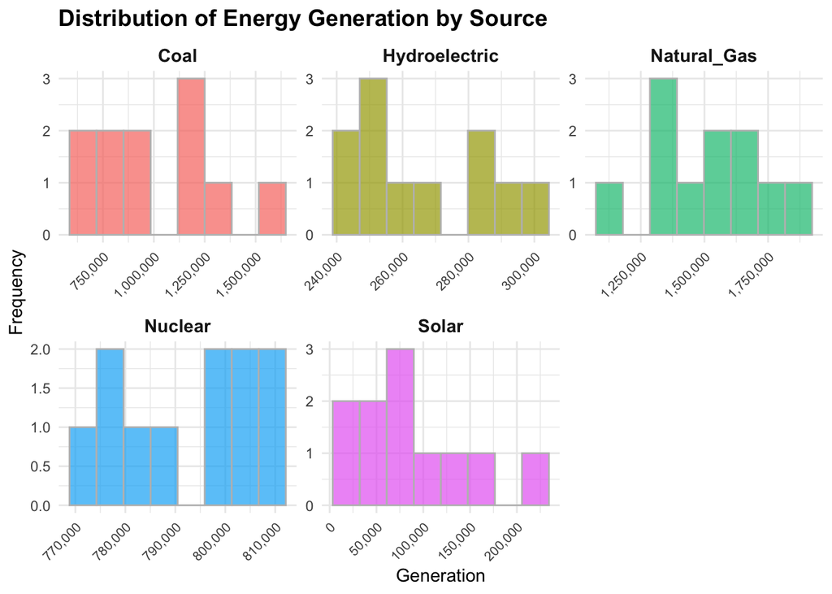

```r
energy_long <- data %>%
  select(Coal, Natural_Gas, Nuclear, Hydroelectric, Solar) %>%
  pivot_longer(
    cols = everything(),
    names_to = "Energy_Source",
    values_to = "Generation"
  )

ggplot(energy_long, aes(x = Generation, fill = Energy_Source)) +
  geom_histogram(bins = 8, color = "gray", alpha = 0.7) +
  facet_wrap(~Energy_Source, scales = "free") +
  labs(
    title = "Distribution of Energy Generation by Source",
    x = "Generation",
    y = "Frequency"
  ) +
  scale_x_continuous(labels = scales::comma) +
  theme_minimal() +
  theme(
    legend.position = "none",
    axis.text.x = element_text(size = 8, angle = 45, hjust = 1),
    strip.text = element_text(face = "bold", size = 11),
    plot.title = element_text(face = "bold", size = 14)
    )
```

**Observation**

The distribution plots show clear differences in stability and growth across the major energy sources. Coal and natural gas display wider distributions, reflecting larger variation over time and major structural changes in the U.S. energy mix. Coal shows a spread with values shifting downward across the period, supporting its long-term decline, while natural gas shows a wider upper range, reflecting its steady increase and growing role as a primary energy source.

Nuclear and hydroelectric generation appear much more stable with narrow distributions and less variation across years, suggesting these sources maintained consistent output throughout the study period and did not experience major structural shifts.

Solar shows the strongest right-skewed distribution with most values concentrated at lower levels and few much higher values in recent years. This pattern reflects growth over time, where solar generation started small at scale but expanded significantly during the later years of the study period.

## Box Plot Comparison

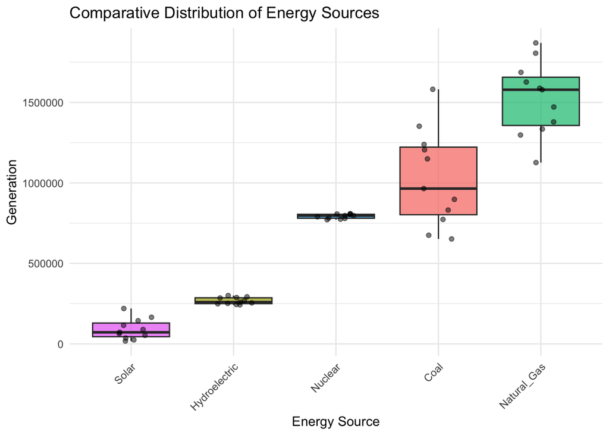

```r
ggplot(energy_long, aes(
  x = reorder(Energy_Source, Generation, FUN = median),
  y = Generation,
  fill = Energy_Source
)) +
  geom_boxplot(alpha = 0.7) +
  geom_jitter(width = 0.2, alpha = 0.5) +
  labs(
    title = "Comparative Distribution of Energy Sources",
    x = "Energy Source",
    y = "Generation"
  ) +
  theme_minimal() +
  theme(
    legend.position = "none",
    axis.text.x = element_text(angle = 45, hjust = 1)
  )
```

**Observation**

The box plot compares the spread, center, and variability of energy generation across sources in the dataset. Natural gas has the highest median generation and a relatively wide spread, showing that it remained the largest energy source in the dataset while also increasing over time. Coal has a lower median than natural gas and a much wider distribution, which reflects its substantial decline across the study period and greater variation from year to year.

Nuclear shows a narrow box and short whiskers, indicating that its generation remained highly stable over time with little variation. Hydroelectric is also stable, though it shows more spread than nuclear, suggesting small fluctuations across the years without a long-term trend.

Solar has the lowest median generation but the widest relative spread compared with its scale. This indicates that solar began at much lower levels but changed over time, which is consistent with its growth across the period. The individual points also show that the later solar values are much higher than the earlier ones.

## Fossil Fuel and Renewable Totals

```r
data <- data %>%
  mutate(
    Fossil_Total = Coal + Natural_Gas,
    Renewable_Total = Hydroelectric + Solar,
    Low_Carbon_Total = Nuclear + Hydroelectric + Solar
  )

#show in clean table
data %>%
  select(Year, Fossil_Total, Renewable_Total, Low_Carbon_Total) %>%
  head() %>%
  mutate(across(-Year, scales::comma)) %>%
  kable(
    caption = "Preview of Fossil Fuel and Renewable Energy Totals",
    align = "c"
  ) %>%
  kable_styling(
    full_width = FALSE,
    bootstrap_options = c("striped", "hover", "condensed"),
    position = "center"
  ) %>%
  row_spec(0, bold = TRUE, font_size = 14) %>%
  column_spec(1, bold = TRUE)
```

Preview of Fossil Fuel and Renewable Energy Totals

| Year | Fossil_Total | Renewable_Total | Low_Carbon_Total |
| --- | --- | --- | --- |
| 2014 | 2,708,345 | 277,058 | 1,074,224 |
| 2015 | 2,687,066 | 273,973 | 1,071,151 |
| 2016 | 2,618,420 | 303,866 | 1,109,560 |
| 2017 | 2,503,538 | 353,620 | 1,158,570 |
| 2018 | 2,621,330 | 356,349 | 1,163,433 |
| 2019 | 2,553,490 | 359,811 | 1,169,220 |

**Observation**

When including low-carbon energy (which adds nuclear), total clean energy is noticeably higher and continues to increase over time, supported by stable nuclear output and growing renewable.

This pattern suggests an ongoing transition in the energy mix, where fossil fuels are gradually declining while renewable energy sources continue to expand, although not yet a scale sufficient to surpass fossil fuel.

## Descriptive Statistics

```r
desc_stats <- data %>%
  summarise(
    Coal_Mean = mean(Coal, na.rm = TRUE),
    Natural_Gas_Mean = mean(Natural_Gas, na.rm = TRUE),
    Nuclear_Mean = mean(Nuclear, na.rm = TRUE),
    Hydroelectric_Mean = mean(Hydroelectric, na.rm = TRUE),
    Solar_Mean = mean(Solar, na.rm = TRUE),
    Fossil_Mean = mean(Fossil_Total, na.rm = TRUE),
    Renewable_Mean = mean(Renewable_Total, na.rm = TRUE),
    Low_Carbon_Mean = mean(Low_Carbon_Total, na.rm = TRUE),

    Coal_SD = sd(Coal, na.rm = TRUE),
    Natural_Gas_SD = sd(Natural_Gas, na.rm = TRUE),
    Nuclear_SD = sd(Nuclear, na.rm = TRUE),
    Hydroelectric_SD = sd(Hydroelectric, na.rm = TRUE),
    Solar_SD = sd(Solar, na.rm = TRUE),
    Fossil_SD = sd(Fossil_Total, na.rm = TRUE),
    Renewable_SD = sd(Renewable_Total, na.rm = TRUE),
    Low_Carbon_SD = sd(Low_Carbon_Total, na.rm = TRUE)
  ) %>%
  pivot_longer(cols = everything()) %>%
  separate(name, into = c("Energy_Source", "Statistic"), sep = "_(?=[^_]+$)") %>%
  pivot_wider(names_from = Statistic, values_from = value) %>%
  mutate(across(c(Mean, SD), round, 2))
```

## Table 1: Energy Sources

```r
desc_stats %>%
  filter(Energy_Source %in% c(
    "Coal", "Natural_Gas", "Nuclear", "Hydroelectric", "Solar"
  )) %>%
  arrange(desc(Mean)) %>%
  kable(caption = "Descriptive Statistics: Energy Source") %>%
  kable_styling(full_width = FALSE, position = "center")
```

Descriptive Statistics: Energy Source

| Energy_Source | Mean | SD |
| --- | --- | --- |
| Natural_Gas | 1524333.00 | 226317.40 |
| Coal | 1029428.27 | 298808.99 |
| Nuclear | 792661.82 | 13807.39 |
| Hydroelectric | 266957.82 | 20889.95 |
| Solar | 91027.27 | 63889.87 |

**Observation**

Fossil fuels have the highest average generation, influenced by natural gas. Coal shows the greatest variability, indicating a decline over time, while nuclear remains stable with low variation. The results suggest a shift within fossil fuels from coal toward natural gas, with nuclear providing consistent output.

## Aggregated Totals Table

```r
desc_stats %>%
  filter(Energy_Source %in% c(
    "Fossil", "Renewable", "Low_Carbon"
  )) %>%
  arrange(desc(Mean)) %>%
  kable(caption = "Descriptive Statistics: Aggregated Energy Totals") %>%
  kable_styling(full_width = FALSE, position = "center")
```

Descriptive Statistics: Aggregated Energy Totals

| Energy_Source | Mean | SD |
| --- | --- | --- |
| Fossil | 2553761.3 | 94813.49 |
| Low_Carbon | 1150646.9 | 50038.02 |
| Renewable | 357985.1 | 56826.21 |

**Observations**

The aggregated totals display the structure of the energy system in the U.S. Fossil fuels have the highest average generation, significantly exceeding both low-carbon and renewable energy totals, indicating continued dependence on fossil energy sources.

Low-carbon energy, which includes nuclear, hydroelectric, and solar, has a substantially higher mean than renewable energy, reflecting the important role of nuclear power in the clean energy mix.

Renewable energy, while much smaller in magnitude, shows comparable variability to low-carbon totals, suggesting growth over time influenced primarily by solar expansion.

These results indicate that although fossil fuels remain the primary energy source, low-carbon and renewable energy sources are increasing, supporting evidence of a gradual transition toward clean energy.

## Reshape Data for Visualization

```r
long_data <- data %>%
  pivot_longer(
    cols = c(Coal, Natural_Gas, Nuclear, Hydroelectric, Solar),
    names_to = "Energy_Source",
    values_to = "Generation"
  )
```

## Time Series Plot of Energy Sources Over Time

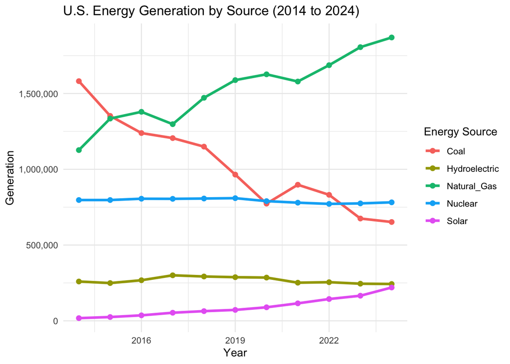

```r
ggplot(long_data, aes(x = Year, y = Generation, color = Energy_Source)) +
  geom_line(linewidth = 1.2) +
  geom_point(size = 2) +
  labs(
    title = "U.S. Energy Generation by Source (2014 to 2024)",
    x = "Year",
    y = "Generation",
    color = "Energy Source"
  ) +
  scale_y_continuous(labels = comma) +
  theme_minimal()
```

## Compare Aggregated Energy Totals Over Time

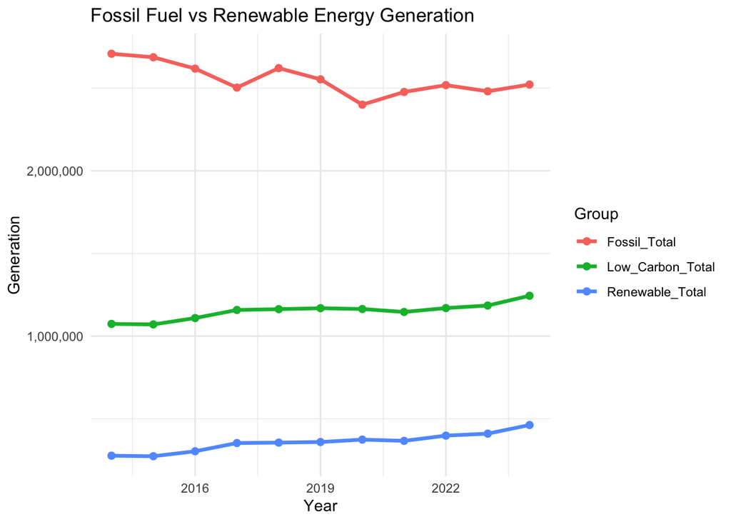

```r
totals_long <- data %>%
  select(Year, Fossil_Total, Renewable_Total, Low_Carbon_Total) %>%
  pivot_longer(
    cols = c(Fossil_Total, Renewable_Total, Low_Carbon_Total),
    names_to = "Group",
    values_to = "Generation"
  )

ggplot(totals_long, aes(x = Year, y = Generation, color = Group)) +
  geom_line(linewidth = 1.2) +
  geom_point(size = 2) +
  labs(
    title = "Fossil Fuel vs Renewable Energy Generation",
    x = "Year",
    y = "Generation",
    color = "Group"
  ) +
  scale_y_continuous(labels = comma) +
  theme_minimal()
```

## Additional Time Series Analysis

Because this dataset is organized by year, additional time series methods can help evaluate whether energy generation values are related to previous years and whether forecasting models may be appropriate. This section adds lag plots, a seasonality limitation note, decomposition, and a preliminary ARIMA model.

```r
#lag plots for selected energy sources

lag_data <- data %>%
  arrange(Year) %>%
  mutate(
    Coal_Lag1 = lag(Coal),
    Natural_Gas_Lag1 = lag(Natural_Gas),
    Solar_Lag1 = lag(Solar),
    Renewable_Total_Lag1 = lag(Renewable_Total)
  )
```

## Lag Plot: Coal Generation

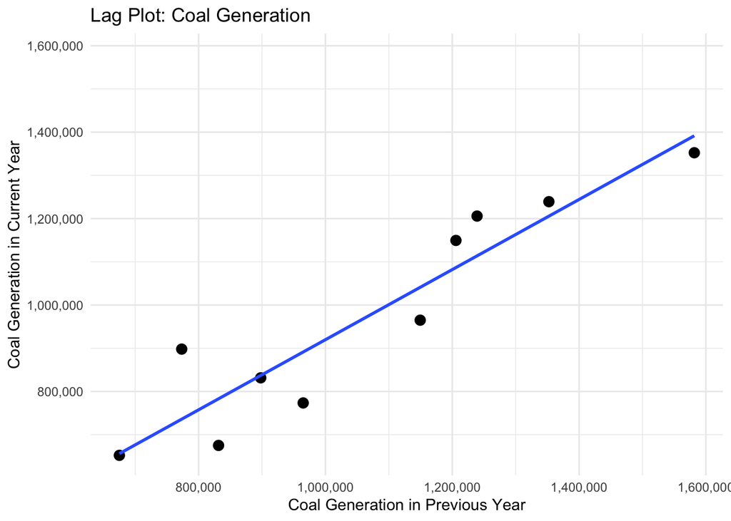

```r
#Create lag plot for coal generation
ggplot(lag_data, aes(x = Coal_Lag1, y = Coal)) +
  geom_point(size = 3) +
  geom_smooth(method = "lm", se = FALSE) +
  labs(
    title = "Lag Plot: Coal Generation",
    x = "Coal Generation in Previous Year",
    y = "Coal Generation in Current Year"
  ) +
  scale_x_continuous(labels = comma) +
  scale_y_continuous(labels = comma) +
  theme_minimal()
```

**Observation**

The lag plot shows a strong positive relationship between coal generation in the previous year and coal generation in the current year. Years with higher coal generation tend to be followed by years with similarly higher coal generaiton, while lower-generation years tend to follow lower-generation years. This suggests that coal generation has autocorrelation, meaning values are not independent year to year. However, there is spread around the trend line, so year-to-year changes still occur rather than coal generation following the exact same pattern every year.

## Lag Plot: Solar Generation

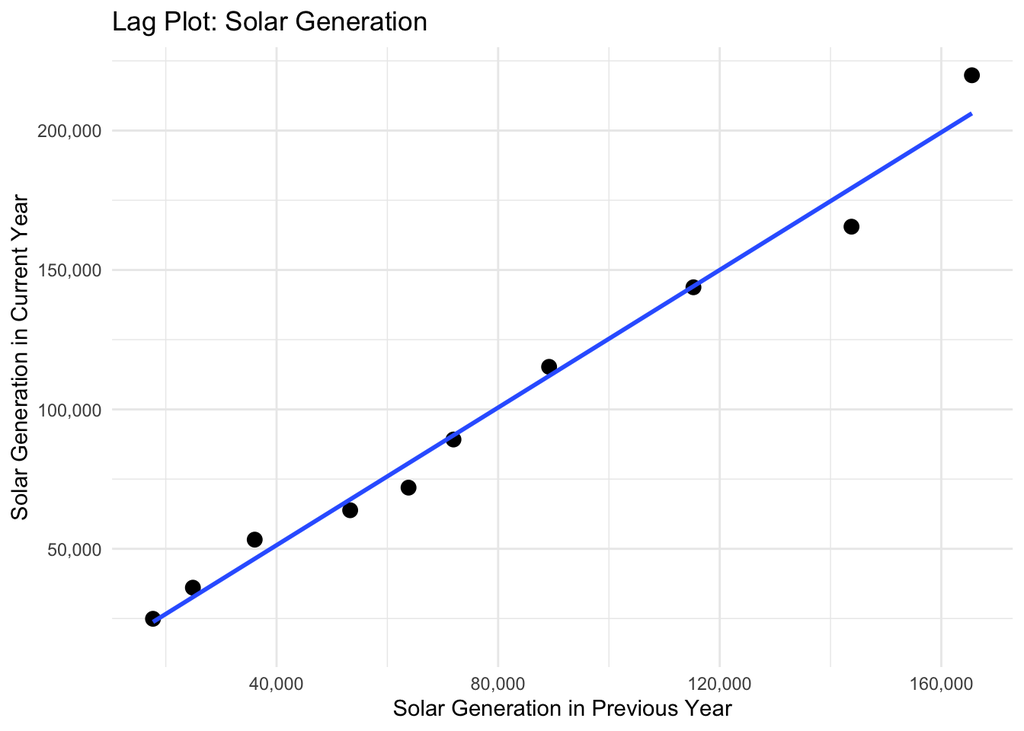

```r
#Create lag plot for solar generation
ggplot(lag_data, aes(x = Solar_Lag1, y = Solar)) +
  geom_point(size = 3) +
  geom_smooth(method = "lm", se = FALSE) +
  labs(
    title = "Lag Plot: Solar Generation",
    x = "Solar Generation in Previous Year",
    y = "Solar Generation in Current Year"
  ) +
  scale_x_continuous(labels = comma) +
  scale_y_continuous(labels = comma) +
  theme_minimal()
```

**Observation**

The lag for solar generation shows a strong positive autocorrelation, meaning current-year generation is closely related to the previous year. The upward pattern suggests steady growth over time.

## Seasonality Limitation

Traditional seasonal analysis is limited in this project because the dataset contains annual observations rather than monthly or quarterly observations. Seasonal patterns usually require data with repeated observations within each year, such as monthly electricity generation. Because this dataset only includes one value per year, it cannot fully show seasonal changes related to weather, heating demand, cooling demand, or daylight patterns.

As a result, seasonal plots and seasonal decomposition are not fully appropriate for this dataset. A stronger future version of this project would use monthly EIA data to evaluate seasonality.

## Time Series Trend Plot and Decomposition Limitation

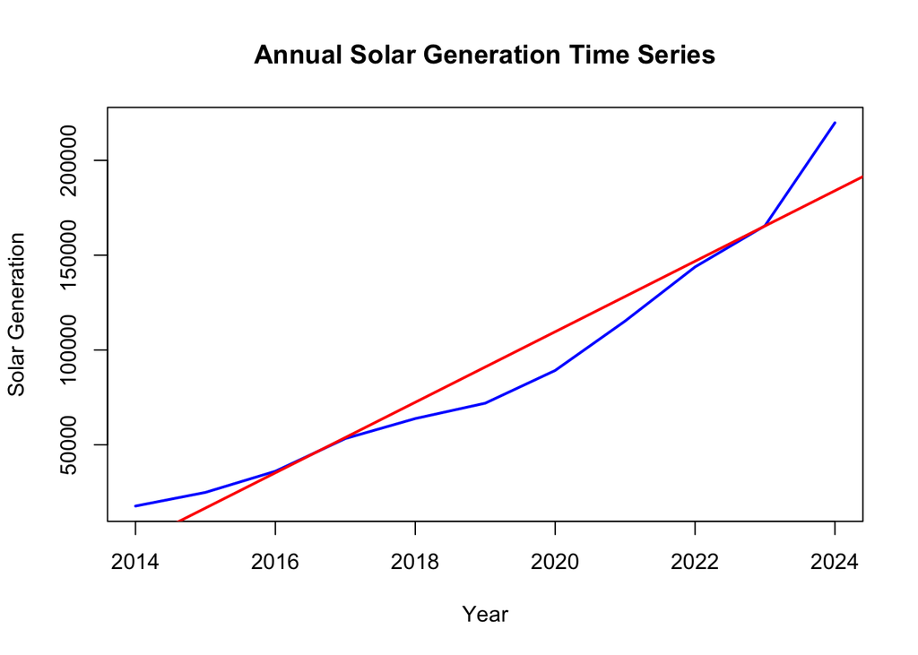

```r
#Create annual time series object for solar generation
solar_ts <- ts(data$Solar, start = min(data$Year), frequency = 1)

#Plot annual solar generation trend instead of seasonal decomposition
plot(
  solar_ts,
  main = "Annual Solar Generation Time Series",
  xlab = "Year",
  ylab = "Solar Generation",
  col = "blue",
  lwd = 2
)

#Add a trend line
abline(
  lm(as.numeric(solar_ts) ~ time(solar_ts)),
  col = "red",
  lwd = 2
)
```

**Observation**

Solar generation increased steadily from 2014 to 2024, with growth accelerating after 2020. The blue line rises above the trend line near the end, suggesting recent solar growth was stronger than the overall trend line.

## Preliminary ARIMA Forecast for Solar Generation

```r
#Fit preliminary ARIMA model for solar generation
#Fit preliminary ARIMA model for solar generation
solar_arima <- forecast::auto.arima(solar_ts)

#Create ARIMA model summary table
arima_summary_table <- data.frame(
  Metric = c(
    "Selected ARIMA Model",
    "AIC",
    "AICc",
    "BIC",
    "Log Likelihood",
    "Sigma Squared"
  ),
  Value = c(
    as.character(solar_arima),
    round(solar_arima$aic, 2),
    round(solar_arima$aicc, 2),
    round(solar_arima$bic, 2),
    round(solar_arima$loglik, 2),
    round(solar_arima$sigma2, 2)
  )
)

#Display ARIMA model summary table
arima_summary_table %>%
  kable(
    caption = "Preliminary ARIMA Model Summary for Solar Generation",
    align = "c"
  ) %>%
  kable_styling(
    full_width = FALSE,
    bootstrap_options = c("striped", "hover", "condensed"),
    position = "center"
  ) %>%
  row_spec(0, bold = TRUE) %>%
  column_spec(1, bold = TRUE)
```

Preliminary ARIMA Model Summary for Solar Generation

| Metric | Value |
| --- | --- |
| Selected ARIMA Model | ARIMA(0,2,0) |
| AIC | 197.16 |
| AICc | 197.73 |
| BIC | 197.35 |
| Log Likelihood | -97.58 |
| Sigma Squared | 153024088.09 |

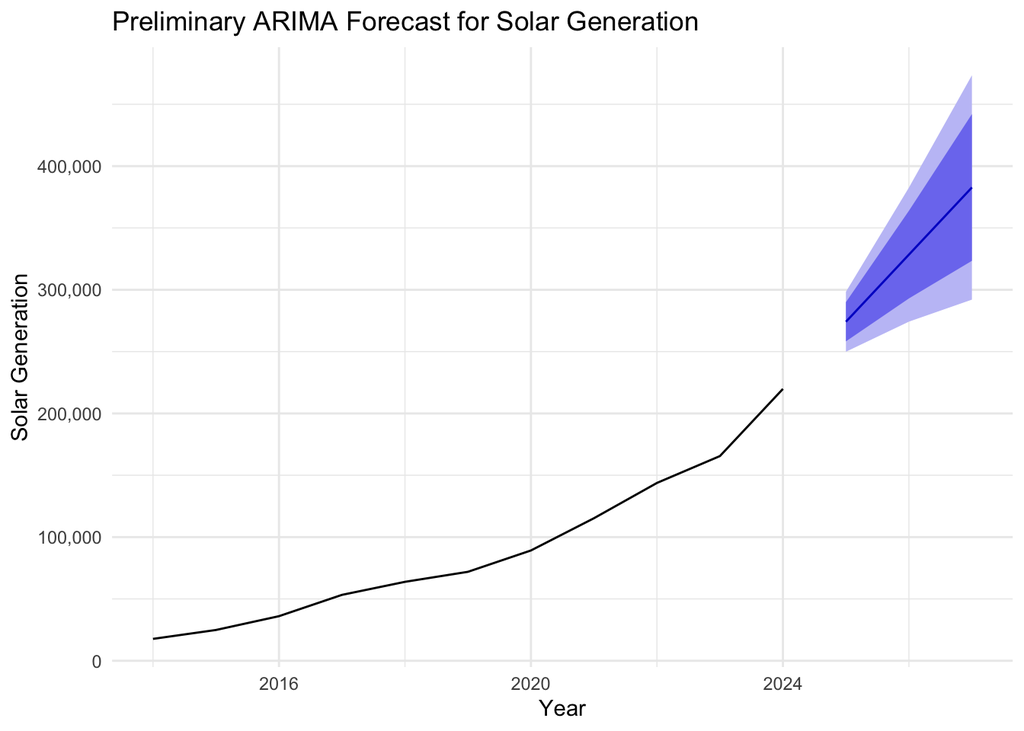

```r
#Forecast solar generation for the next three years
solar_forecast <- forecast::forecast(solar_arima, h = 3)

autoplot(solar_forecast) +
  labs(
    title = "Preliminary ARIMA Forecast for Solar Generation",
    x = "Year",
    y = "Solar Generation"
  ) +
  scale_y_continuous(labels = comma) +
  theme_minimal()
```

**Observation**

The preliminary ARIMA model selected for solar generation is ARIMA(0,2,0), meaning the series required second differencing to handle its strong upward trend. This supports the idea that solar generation is non-stationary and growing over time.

The preliminary ARIMA forecast projects continued growth in solar generation after 2024. The widening shaded bands show increasing uncertainty over time, so the forecast should be interpreted as exploratory rather than a precise prediction.

### Hypothesis Testing Framework

To evaluate trends in energy generation over time, I tested the following hypotheses for each energy source using linear regression.

**Null Hypothesis (H0)**: There is no significant linear relationship between year and energy generation (slope = 0).

**Alternative Hypothesis (H1)**: There is significant linear relationship between year and energy generation (slope ≠ 0).

## Linear Regression Models

```r
model_coal <- lm(Coal ~ Year, data = data)
model_gas <- lm(Natural_Gas ~ Year, data = data)
model_nuclear <- lm(Nuclear ~ Year, data = data)
model_hydro <- lm(Hydroelectric ~ Year, data = data)
model_solar <- lm(Solar ~ Year, data = data)
model_fossil <- lm(Fossil_Total ~ Year, data = data)
model_renewable <- lm(Renewable_Total ~ Year, data = data)
model_low_carbon <-lm(Low_Carbon_Total ~ Year, data = data)
```

## Regression Results Table

```r
results_table <- bind_rows(
  tidy(model_coal) %>% mutate(Model = "Coal"),
  tidy(model_gas) %>% mutate(Model = "Natural Gas"),
  tidy(model_nuclear) %>% mutate(Model = "Nuclear"),
  tidy(model_hydro) %>% mutate(Model = "Hydroelectric"),
  tidy(model_solar) %>% mutate(Model = "Solar"),
  tidy(model_fossil) %>% mutate(Model = "Fossil Total"),
  tidy(model_renewable) %>% mutate(Model = "Renewable Total"),
  tidy(model_low_carbon) %>% mutate(Model = "Low Carbon Total")
) %>%
  filter(term == "Year") %>%
  select(Model, estimate, std.error, statistic, p.value) %>%
  rename(
    Slope = estimate,
    `Std. Error` = std.error,
    `t-value` = statistic,
    `p-value` = p.value
  ) %>%
  mutate(
    Slope = round(Slope, 2),
    `Std. Error` = round(`Std. Error`, 2),
    `t-value` = round(`t-value`, 2),
    `p-value` = ifelse(
      `p-value` < 0.001,
      "< 0.001",
      sprintf("%.3f", `p-value`)
    )
  )

  results_table %>%
    kable(
      caption = "Linear Regression Results for Energy Regression by Year",
      align = "c"
    ) %>%
    kable_styling(
      full_width = FALSE,
      bootstrap_options = c("striped","hover","condensed"),
      position = "center"
    ) %>%
    row_spec(0, bold = TRUE, font_size = 14) %>%
    row_spec(1:nrow(results_table), font_size = 14) %>%
    column_spec(1, bold = TRUE) %>%
    column_spec(2, color = "darkblue") %>%
    column_spec(5, bold = TRUE, color = "darkred")
```

Linear Regression Results for Energy Regression by Year

| Model | Slope | Std. Error | t-value | p-value |
| --- | --- | --- | --- | --- |
| Coal | -87014.35 | 7785.21 | -11.18 | < 0.001 |
| Natural Gas | 65847.44 | 5966.94 | 11.04 | < 0.001 |
| Nuclear | -3054.65 | 942.83 | -3.24 | 0.010 |
| Hydroelectric | -2204.38 | 1966.74 | -1.12 | 0.291 |
| Solar | 18598.12 | 1673.10 | 11.12 | < 0.001 |
| Fossil Total | -21166.92 | 6404.84 | -3.30 | 0.009 |
| Renewable Total | 16393.74 | 1660.34 | 9.87 | < 0.001 |
| Low Carbon Total | 13339.09 | 2349.64 | 5.68 | < 0.001 |

**Hypothesis Decisions**

**Reject H0 (significant trends)**

**Reason**: **p < 0.05**

**Coal** (p < 0.001) **Natural Gas** (p < 0.001) **Nuclear** (p = 0.010) **Solar** (p < 0.001)

**Aggregated Totals**

**Fossil Total** (p = 0.009) **Renewable Total** (p < 0.001) **Low Carbon Total** (p < 0.001)

**Fail to Reject H0 (Not significant)**

**Reason**: **p > 0.05**

**Hydroelectric** (p = 0.291)

**Hypothesis Testing Results**

Based on the regression results, the null hypothesis is rejected for coal, natural gas, nuclear, solar, in addition to the aggregated energy totals: fossil fuel total, renewable total, and low carbon total, since the corresponding p-values are below the 0.05 significance level. This indicates statistically significant trends in these energy sources over time.

In contrast, the null hypothesis is not rejected for hydroelectric energy (p = 0.291), suggesting no statistically significant trend and relatively stable generation over the study period.

These results provide evidence of structural changes in the energy system, characterized by declining coal usage, increasing natural gas and solar generation, and overall growth in renewable and low-carbon energy sources. Low-carbon energy includes renewable sources and therefore overlaps with the renewable category.

## Model Fit (R² Values)

```r
r2_table <- bind_rows(
  glance(model_coal) %>% mutate(Model = "Coal"),
  glance(model_gas) %>% mutate(Model = "Natural Gas"),
  glance(model_nuclear) %>% mutate(Model = "Nuclear"),
  glance(model_hydro) %>% mutate(Model = "Hydroelectric"),
  glance(model_solar) %>% mutate(Model = "Solar"),
  glance(model_fossil) %>% mutate(Model = "Fossil Totals"),
  glance(model_renewable) %>% mutate(Model = "Renewable Total"),
  glance(model_low_carbon) %>% mutate(Model = "Low Carbon Total")
) %>%
  select(Model, r.squared, adj.r.squared) %>%
  mutate(
    r.squared = round(r.squared, 3),
    adj.r.squared = round(adj.r.squared, 3)
    )

  r2_table %>%
    kable(
      caption = "Model Fit Statistics (R² and Adjusted R²)",
      align = "c"
    ) %>%
    kable_styling(full_width = FALSE, position = "center")
```

Model Fit Statistics (R² and Adjusted R²)

| Model | r.squared | adj.r.squared |
| --- | --- | --- |
| Coal | 0.933 | 0.925 |
| Natural Gas | 0.931 | 0.924 |
| Nuclear | 0.538 | 0.487 |
| Hydroelectric | 0.122 | 0.025 |
| Solar | 0.932 | 0.925 |
| Fossil Totals | 0.548 | 0.498 |
| Renewable Total | 0.915 | 0.906 |
| Low Carbon Total | 0.782 | 0.757 |

**Observation**

The model fit statistics indicate that the model explains a large proportion of the variation in several energy sources. Coal, natural gas, and solar all show very high R² values **(above 0.93)**, suggesting consistent linear trends. Renewable energy total shows a high R² value **(0.915)**, indicating an upward trend influenced primarily by solar growth.

Low-carbon energy totals show a moderately high R² value **(0.782)**, reflecting a consistent trend due to the stabilizing effect of nuclear energy. In contrast, fossil fuel totals have a moderate R² **(0.548)**, suggesting a weaker trend as the decline in coal is partially offset by the increase in natural gas.

Hydroelectric energy has a very low R² value **(0.122)**, indicating that time does not explain much of its variation and supporting the earlier finding of no statistically significant trend.

## Diagnostic Plots

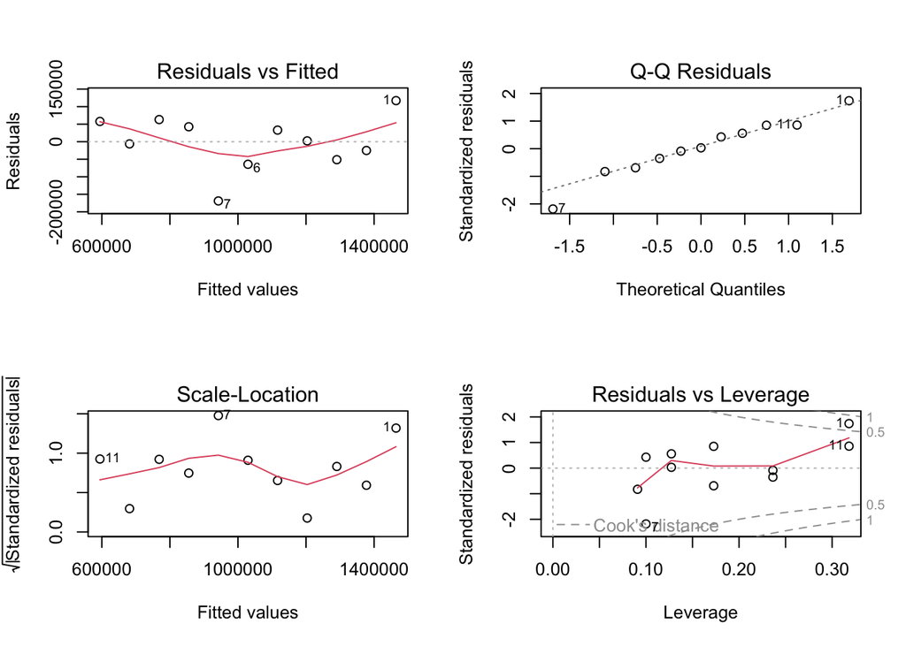

```r
par(mfrow = c(2,2))
plot(model_coal)
```

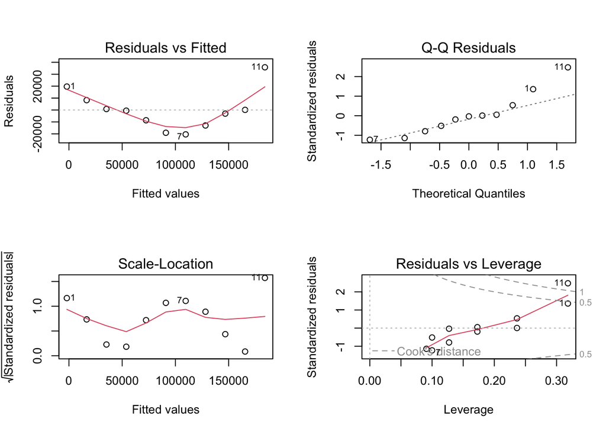

```r
par(mfrow = c(2,2))
plot(model_solar)
```

## Observation

The diagnostic plots indicate that the linear model is more appropriate for coal. The residuals for coal appear randomly scattered around zero, suggesting that the assumptions of linearity are reasonably satisfied. The Q-Q plot also indicates approximate normality of residuals, and no highly influential outliers.

In contrast, the solar model shows a curved pattern in the residuals, suggesting a violation in the linearity assumption and indicating that a nonlinear model may better display its growth pattern. While residuals remain approximately normally distributed, the increasing spread of residuals at higher fitted values suggests mild heteroscedasticity.

These results indicate that coal follows a stable linear decline, while solar displays a more dynamic and accelerating growth pattern that is not fully displayed by a linear model.

## Scatterplot with Regression Line for Coal

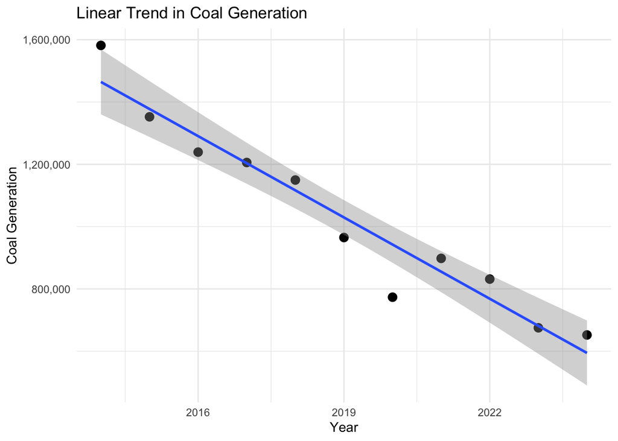

```r
ggplot(data, aes(x = Year, y = Coal)) +
  geom_point(size = 3) +
  geom_smooth(method = "lm", se = TRUE) +
  labs(
    title = "Linear Trend in Coal Generation",
    x = "Year",
    y = "Coal Generation"
  ) +
  scale_y_continuous(labels = comma) +
  theme_minimal()
```

## Scatterplot with Regression Line for Natural Gas

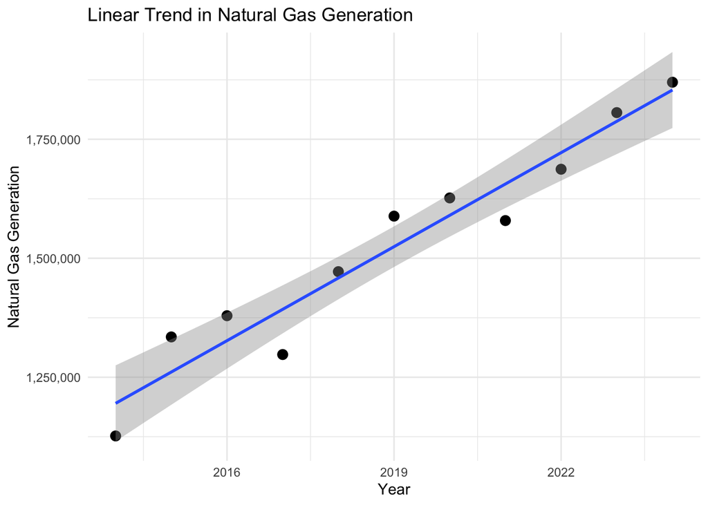

```r
ggplot(data, aes(x = Year, y = Natural_Gas)) +
  geom_point(size = 3) +
  geom_smooth(method = "lm", se = TRUE) +
  labs(
    title = "Linear Trend in Natural Gas Generation",
    x = "Year",
    y = "Natural Gas Generation"
  ) +
  scale_y_continuous(labels = comma) +
  theme_minimal()
```

## Scatterplot with Regression Line for Solar

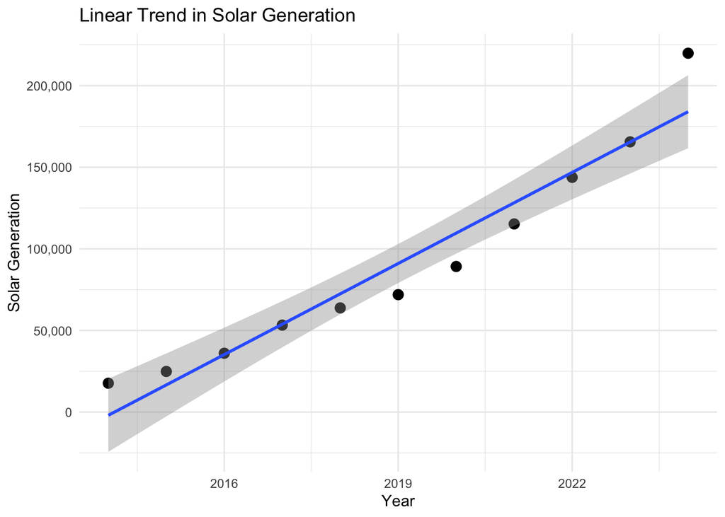

```r
ggplot(data, aes(x = Year, y = Solar)) +
  geom_point(size = 3) +
  geom_smooth(method = "lm", se = TRUE) +
  labs(
    title = "Linear Trend in Solar Generation",
    x = "Year",
    y = "Solar Generation"
  ) +
  scale_y_continuous(labels = comma) +
  theme_minimal()
```

## Scatterplot with Regression Line for Renewable Total

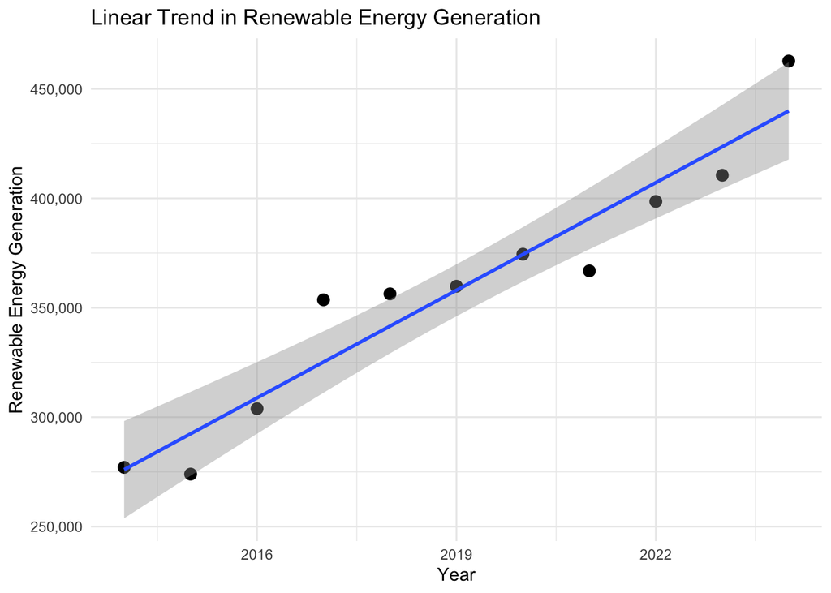

```r
ggplot(data, aes(x = Year, y = Renewable_Total)) +
  geom_point(size = 3) +
  geom_smooth(method = "lm", se = TRUE) +
  labs(
    title = "Linear Trend in Renewable Energy Generation",
    x = "Year",
    y = "Renewable Energy Generation"
  ) +
  scale_y_continuous(labels = comma) +
  theme_minimal()
```

**Observation**

The scatterplots with regression lines display trends across the energy system. Coal shows a downward trend, reflecting its statistically significant decline over time. In contrast, natural gas shows a strong upward trend, indicating its increasing role as a primary energy source and highlight a shift within fossil fuels. Solar shows the most increase in growth with a positive trend that reflects its expanding contribution to renewable energy.

At the system level, the aggregated renewable energy total shows a consistent upward trend, confirming the growth of clean energy sources. Together, these patterns display visual evidence of an energy transition, characterized by declining coal use, increasing dependence on natural gas, and the expansion of renewable energy.

## Correlation Matrix

```r
cor_matrix <- data %>%
  select(Coal, Natural_Gas, Nuclear, Hydroelectric, Solar) %>%
  cor(use = "complete.obs")

  cor_matrix %>%
  round(2) %>%
  as.data.frame() %>%
  tibble::rownames_to_column("Variable") %>%
  kable(
    caption = "Correlation Matrix of Energy Sources",
    align = "c"
  ) %>%
  kable_styling(
    full_width = FALSE,
    bootstrap_options = c("striped", "hover", "condensed"),
    position = "center"
  ) %>%
  row_spec(0, bold = TRUE, font_size = 14) %>%
  column_spec(1, bold = TRUE, width = "2.5in")
```

Correlation Matrix of Energy Sources

| Variable | Coal | Natural_Gas | Nuclear | Hydroelectric | Solar |
| --- | --- | --- | --- | --- | --- |
| Coal | 1.00 | -0.97 | 0.64 | 0.23 | -0.89 |
| Natural_Gas | -0.97 | 1.00 | -0.65 | -0.35 | 0.92 |
| Nuclear | 0.64 | -0.65 | 1.00 | 0.72 | -0.76 |
| Hydroelectric | 0.23 | -0.35 | 0.72 | 1.00 | -0.48 |
| Solar | -0.89 | 0.92 | -0.76 | -0.48 | 1.00 |

**Observation**

The correlation matrix reveals patterns in the transition of energy sources over time. Coal displays a negative correlation with both natural **(-0.97)** and solar **(-0.89)**, indicating that as clean energy sources increased, coal usage declined significantly. In contrast, natural gas and solar are strongly positively correlated **(0.92)**, suggesting they have grown together as alternatives to coal.

```r
agg_cor_matrix <- data %>%
  select(Fossil_Total, Renewable_Total) %>%
  cor(use = "complete.obs")

  agg_cor_matrix %>%
  round(2) %>%
  as.data.frame() %>%
  tibble::rownames_to_column("Variable") %>%
  kable(
    caption = "Correlation Matrix of Aggregated Energy Totals",
    align = "c"
  ) %>%
  kable_styling(
    full_width = FALSE,
    bootstrap_options = c("striped", "hover", "condensed"),
    position = "center"
  ) %>%
  row_spec(0, bold = TRUE, font_size = 14) %>%
  column_spec(1, bold = TRUE, width = "2.5in")
```

Correlation Matrix of Aggregated Energy Totals

| Variable | Fossil_Total | Renewable_Total |
| --- | --- | --- |
| Fossil_Total | 1.00 | -0.72 |
| Renewable_Total | -0.72 | 1.00 |

**Observation**

The correlation matrix shows a negative relationship between fossil fuels and renewable energy **(-0.72)**, indicating that as renewable generation increases, fossil fuel dependence decreases. This pattern supports a structural shift in the energy mix, although it doesn’t imply a direct relationship.

## Heat map

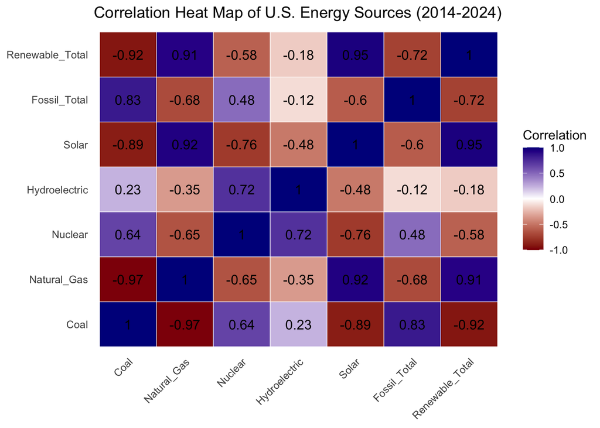

```r
cor_matrix <- data %>%
  select(Coal, Natural_Gas, Nuclear, Hydroelectric, Solar, Fossil_Total, Renewable_Total) %>%
  cor(use = "complete.obs")

cor_df <- as.data.frame(as.table(cor_matrix))

ggplot(cor_df, aes(x = Var1, y = Var2, fill = Freq)) +
  geom_tile(color = "white") +
  geom_text(aes(label = round(Freq, 2)), size = 4) +
  scale_fill_gradient2(
    low = "darkred",
    mid = "white",
    high = "darkblue",
    midpoint = 0,
    limits = c(-1, 1)
  ) +
  labs(
    title = "Correlation Heat Map of U.S. Energy Sources (2014-2024)",
    x = NULL,
    y = NULL,
    fill = "Correlation"
  ) +
  theme_minimal() +
  theme(
    axis.text.x = element_text(angle = 45, hjust = 1),
    panel.grid = element_blank()
  )
```

**Observation**

The heat map represents a visual confirmation of a shift in the energy mix over time. Coal is negatively correlated with renewable energy **(-0.92)** and solar **(-0.89)**, indicating that as coal declines, renewables rise. In contrast, natural gas is positively correlated with both solar **(0.92)** and renewable energy **(0.91)**, suggesting it is increasing alongside renewables rather than being replaced, reinforcing its role as a transitional energy source. Solar has the strongest relationship with renewable energy **(0.95)**, indicating it is the primary influencer of renewable growth, while nuclear and hydroelectric show less consistent patterns.

## Conclusion

This analysis provides statistical evidence of changes in U.S. generation from 2014 to 2024 and shows meaningful signs of a transition from the use of fossil fuels toward renewable energy sources. However, these results indicate that the transition is ongoing.

Total renewable energy generation also increased significantly, confirming the expansion of clean energy sources. Correlation analysis supports these findings by showing negative relationships between coal and renewables, as well as between fossil fuels and renewable energy. These results show that as renewable energy grows, the dependence on coal continues to decline.

These results suggest a partial and evolving energy transition rather than a complete replacement of fossil fuels. Coal is steadily declining, renewables are growing, nuclear is stable, and natural gas continues to fill the gap between traditional and clean energy systems. Moving toward a fully decarbonized energy system will require investment in renewable energy, grid infrastructure, energy storage, and policies that reduce long-term dependence on transition fuels such as natural gas.

## Limitations

This analysis has several limitations. First, the dataset covers a relatively short time period (2014-2024), which may limit the ability to showcase long-term energy trends. Second, the linear regression models assume a linear relationship over time, which may simplify more complex or nonlinear changes in energy generation. Additionally, the analysis does not account for external factors, such as government policy, technological advancements, or economic conditions, which may influence shifts in energy production. Finally, the dataset is aggregated at a national level, which may filter regional variations in energy use and the transition patterns.

## Recommendations for Future Research

Future research could improve this analysis by expanding the timeline to cover a longer period, such as 1995 to 2024, to better show major policy shifts and long-term changes in U.S. energy generation. Testing non-linear models, such as exponential or polynomial regression would also be useful, especially for solar energy, since its recent substantial growth is not represented by a linear trend.

Additionally, the inclusion of external factors such as government policies, technology costs, and natural gas prices could help explain why these changes occur. A state-level analysis would also provide stronger insight, since energy transitions vary significantly across regions depending on local policy and infrastructure.

Using advanced time-series methods such as ARIMA and including demand-side factors like electricity generation and electric vehicle growth would create a more complete understanding of how the U.S. energy system is changing over time.

## What I Learned

This project improved my understanding of regression modeling, my ability to interpret statistical outcomes, and helped me connect quantitative findings to real-world energy policy challenges.

### Technical Skills

In terms of technical skills, I learned how to apply linear regression to time-series data and interpret diagnostic plots to evaluate model assumptions. I also improved my ability to create publication-quality visualizations using R and ggplot2 to communicate statistical relationships. In addition, data manipulation skills using functions such as pivot_longer(), mutate(), and select() to reshape datasets to analysis-ready formats.

### Statistical Thinking

One of the most important lessons was understanding the difference between statistical significance and practical significance. A small p-value does not always indicate a meaningful real-world effect, which made interpreting effect sizes and values equally important. I also learned that model assumptions must be tested before results can be trusted. Diagnostic plots helped show when linear models were appropriate and when non-linear alternatives should be considered. This project also reinforced that statistical interpretation requires domain knowledge, since the meaning of a high R² depends on the context of the analysis.

### Domain Knowledge

The U.S. energy transition is far more nuanced. In this project, I learned that natural gas is not simply being replaced by renewables but is growing alongside them as a transitional fuel. Short-term trends may reflect policy and market shifts rather than long-term equilibrium changes. Events such as the shale revolution and major declines in solar technology costs influenced the shaping of patterns observed in this analysis. Renewable growth is also shaped by infrastructure limits, grid reliability, storage capacity, and policy incentives.

### Communication Skills

Another major takeaway was learning how to communicate quantitative results into explanations for non-technical audiences. Explaining regression slopes, correlation coefficients, and R² values is just as important as calculating them.

### Critical Thinking

My ability to question assumptions and move beyond the results. Along with identifying trends, I learned to ask why those trends exist. For example, Why does natural gas grow alongside renewables? Why might solar follow exponential rather than linear growth? What confounding variables might explain patterns? I also became aware of statistical limitations of statistical analysis, including time constraints, missing external variables, and model assumptions that affect interpretation. Identifying these limitations helped me think critically about what future research would be needed to improve the conclusions.

This project showed me how quantitative analysis, when combined with domain knowledge and critical thinking can support important decisions about energy infrastructure and climate policy.

## Bibliography

1. Hothorn, T. & Everitt, B.S. (2014). *A Handbook of Statistical Analyses using R, 3rd Edition.* Chapman & Hall/CRC.
2. Teetor, P. (2019). *R Cookbook – 2nd Edition.* O’Reilly Media. https://rc2e.com/
3. International Energy Agency. (2023). *Renewables 2024: Analysis and forecasts to 2028.* IEA Publications. https://www.iea.org/reports/renewables-2023
4. U.S. Energy Information Administration. (2025). *Electric Power Annual*. https://www.eia.gov/electricity/annual/table.php?t=epa_03_01_a.html